# Conjugate Families

## Introduction: Beta-Binomial Model

- Last week, we learned how to think like a Bayesian.
  - Today, we will formalize the models we muddled through last time.
- This is called the Beta-Binomial model.
  - The Beta distribution is the *prior*.
  - The Binomial distribution is the *data* distribution (or the *likelihood*).
  - The *posterior* also follows a Beta distribution.
- **Conjugate family**: When the prior and posterior are the same named distribution, but different parameters.

## R Packages Needed

- To follow today’s lecture, please load the following packages:
  - `tidyverse`
  - `janitor`
  - `bayesrules`
  - `ggpubr`

```r
library(tidyverse)
library(janitor)
library(bayesrules)
library(ggpubr)
```

## Example Set Up

- Consider the following scenario.
  - “Michelle” has decided to run for president and you’re her campaign manager for the state of Florida.
  - As such, you’ve conducted 30 different polls throughout the election season.
  - Though Michelle’s support has hovered around 45%, she polled at around 35% in the dreariest days and around 55% in the best days on the campaign trail.
- Past polls provide prior information about $\pi$, the proportion of Floridians that currently support Michelle.

## Beta Prior

- In building the Bayesian election model of Michelle’s election support among Floridians, $\pi$, we begin with the prior.
  - Our continuous prior probability model of $\pi$ is specified by the probability density function (pdf).
- What values can $\pi$ take and which are more plausible than others?

## Beta Prior

- Let $\pi$ be a random variable, where $\pi \in [0, 1]$.
- The variability in $\pi$ may be captured by a Beta model with hyperparameters $\alpha > 0$ and $\beta > 0$,
  - **hyperparameter:** a parameter used in a *prior* model.

$$\pi \sim \text{Beta}(\alpha, \beta)$$

## Beta Prior: Shapes

- Let’s explore the shape of the Beta:

```r
plot_beta(1, 5) + theme_minimal() + ggtitle("Beta(1, 5)")
```

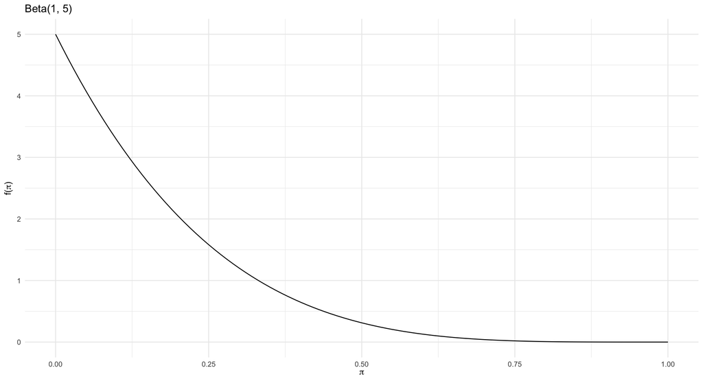

## Beta Prior: Shapes

- Let’s explore the shape of the Beta:

```r
plot_beta(1, 2) + theme_minimal() + ggtitle("Beta(1, 2)")
```

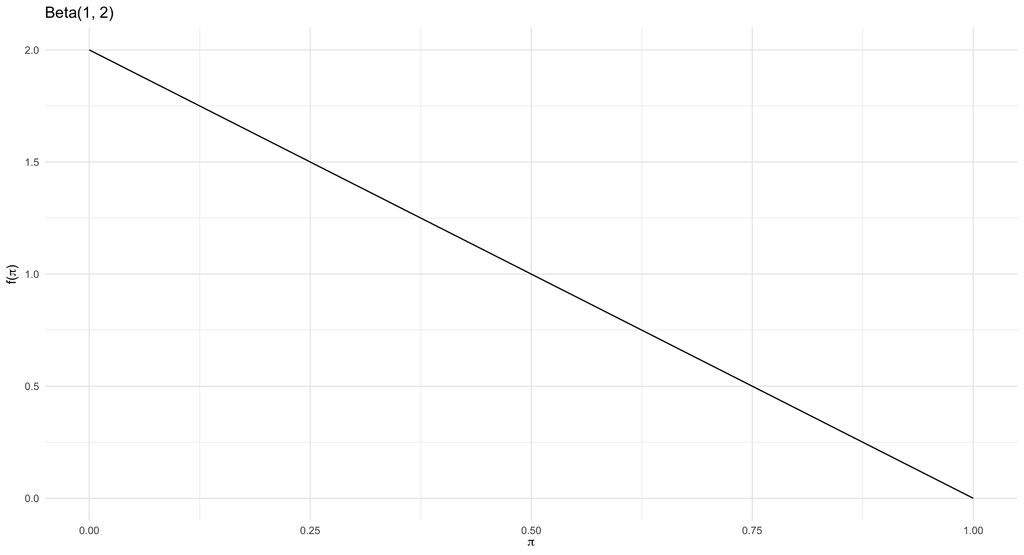

## Beta Prior: Shapes

- Let’s explore the shape of the Beta:

```r
plot_beta(3, 7) + theme_minimal() + ggtitle("Beta(3, 7)")
```

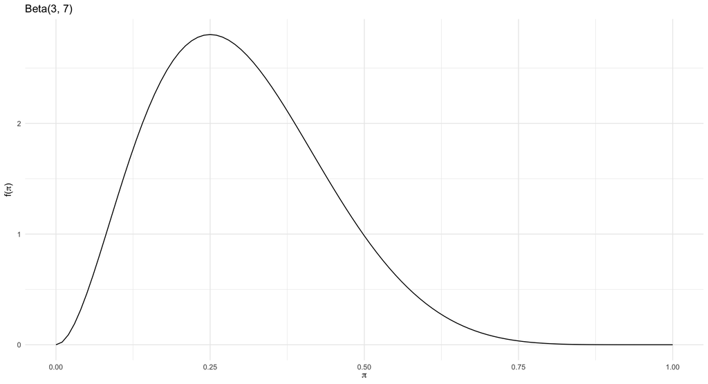

## Beta Prior: Shapes

- Let’s explore the shape of the Beta:

```r
plot_beta(1, 1) + theme_minimal() + ggtitle("Beta(1, 1)")
```

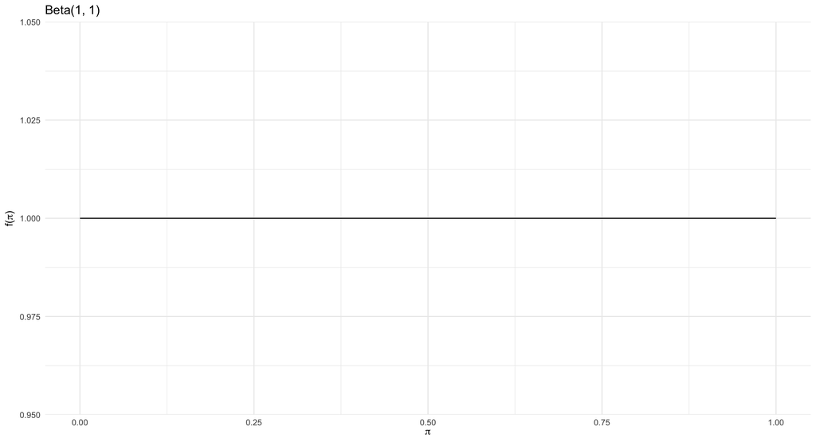

## Beta Prior: Shapes

- Your turn!
- How would you describe the typical behavior of a:
  - Beta($\alpha, \beta$) variable, $\pi$, when $\alpha=\beta$?
  - Beta($\alpha, \beta$) variable, $\pi$, when $\alpha>\beta$?
  - Beta($\alpha, \beta$) variable, $\pi$, when $\alpha<\beta$?
- For which model is there greater variability in the plausible values of $\pi$, Beta(20, 20) or Beta(5, 5)?

## Beta Prior: Shapes

- How would you describe the typical behavior of a Beta($\alpha, \beta$) variable, $\pi$, when $\alpha=\beta$?

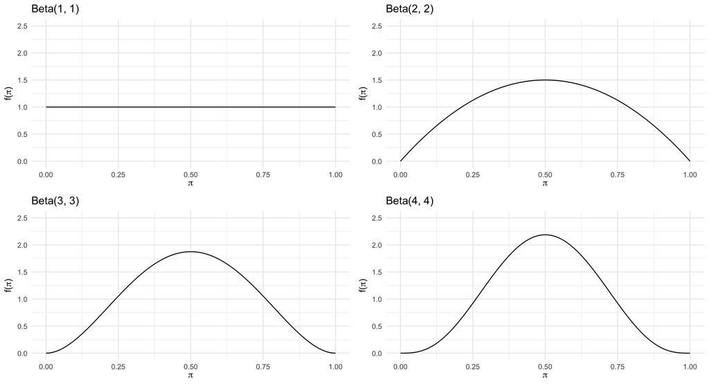

## Beta Prior: Shapes

- How would you describe the typical behavior of a Beta($\alpha, \beta$) variable, $\pi$, when $\alpha>\beta$?

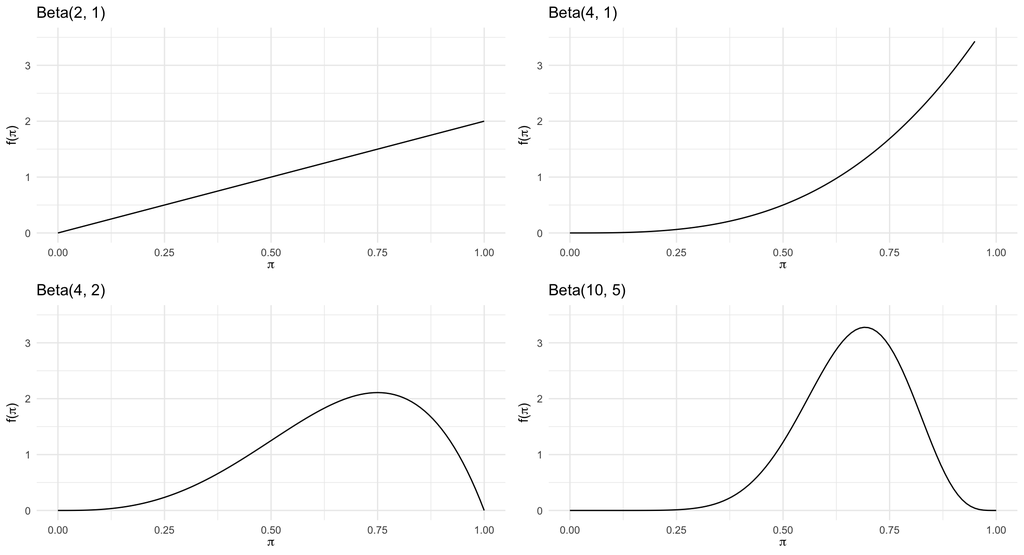

## Beta Prior: Shapes

- How would you describe the typical behavior of a Beta($\alpha, \beta$) variable, $\pi$, when $\alpha<\beta$?

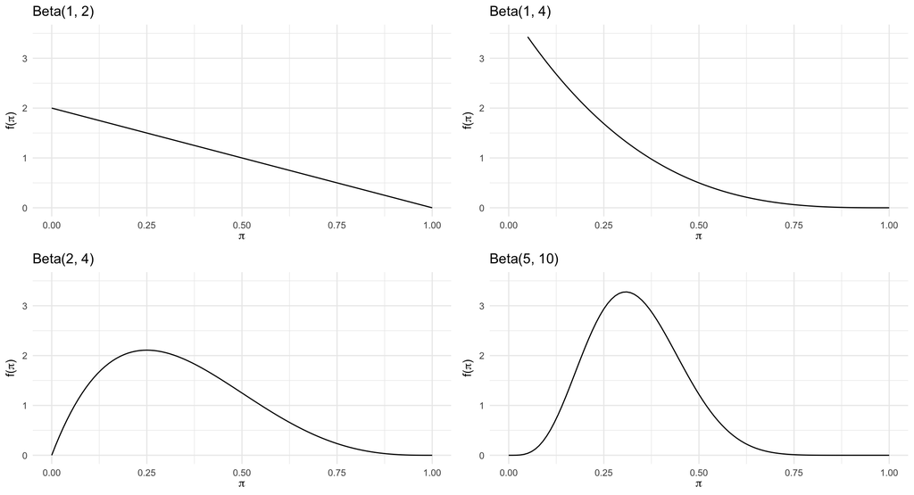

## Beta Prior: Shapes

- For which model is there greater variability in the plausible values of $\pi$, Beta(20, 20) or Beta(5, 5)?

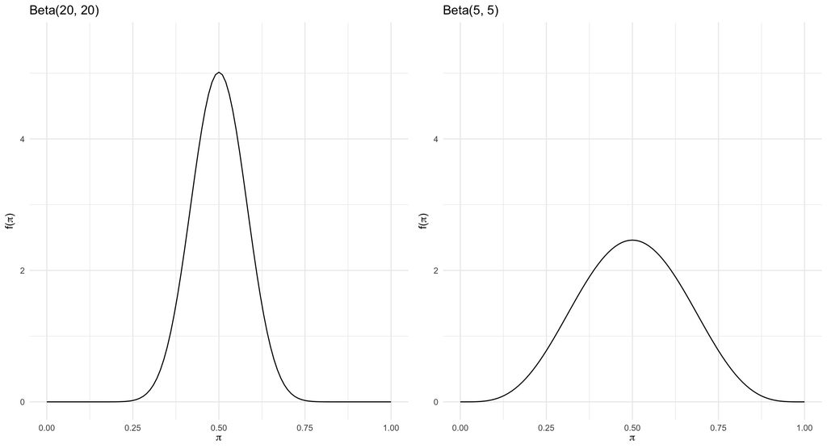

## Tuning the Beta Prior

$$E[\pi] = \frac{\alpha}{\alpha+\beta} \approx 0.45$$

- Using algebra, we can tune, and find

$$\alpha \approx \frac{9}{11} \beta$$

## Tuning the Beta Prior

- Your turn!
  - Graph the following and determine which is best for the example.

```r
plot_beta(9, 11) + theme_minimal() + list(xlim(0, 1), ylim(0, 10))
plot_beta(27, 33) + theme_minimal() + list(xlim(0, 1), ylim(0, 10))
plot_beta(45, 55) + theme_minimal() + list(xlim(0, 1), ylim(0, 10))
```

## Tuning the Beta Prior

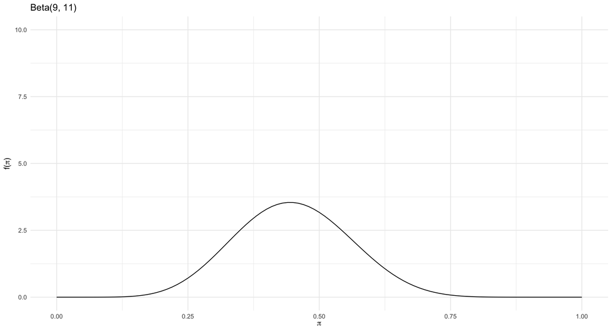

## Tuning the Beta Prior

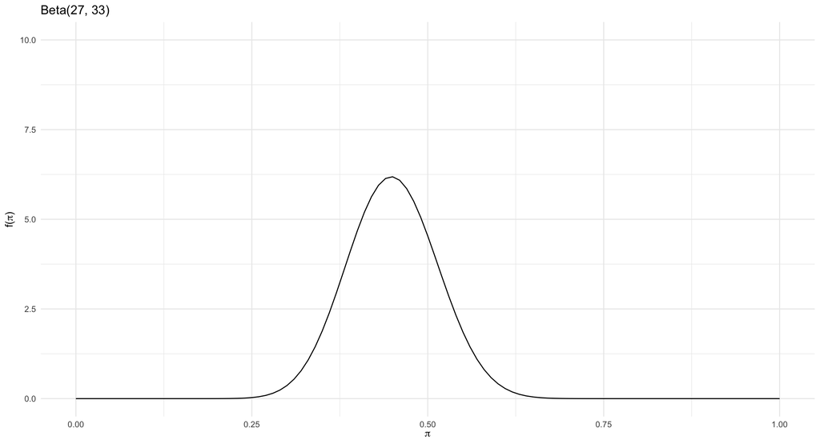